# What are the gender differences in young adults?

by Akash Malla, Santa Clara University (Independent Study Project)

This notebook will analyze Young People survey data from Kaggle. The dataset can be found and downloaded from the below URL: https://www.kaggle.com/miroslavsabo/young-people-survey/data

The objective of this notebook is to identify what attributes describe a person to be a man or a women.

```python
%matplotlib inline
import pandas as pd
import numpy as np
pd.set_option('display.max_columns',150)

#load data
data = pd.read_csv("/Users/akashmalla/Downloads/young-people-survey/responses.csv")

data.head(2)
```

|  | Music | Slow songs or fast songs | Dance | Folk | Country | Classical music | Musical | Pop | Rock | Metal or Hardrock | Punk | Hiphop, Rap | Reggae, Ska | Swing, Jazz | Rock n roll | Alternative | Latino | Techno, Trance | Opera | Movies | Horror | Thriller | Comedy | Romantic | Sci-fi | War | Fantasy/Fairy tales | Animated | Documentary | … |
| --- | --- | --- | --- | --- | --- | --- | --- | --- | --- | --- | --- | --- | --- | --- | --- | --- | --- | --- | --- | --- | --- | --- | --- | --- | --- | --- | --- | --- | --- | --- |
| 0 | 5.0 | 3.0 | 2.0 | 1.0 | 2.0 | 2.0 | 1.0 | 5.0 | 5.0 | 1.0 | 1.0 | 1.0 | 1.0 | 1.0 | 3.0 | 1.0 | 1.0 | 1.0 | 1.0 | 5.0 | 4.0 | 2.0 | 5.0 | 4.0 | 4.0 | 1.0 | 5.0 | 5.0 | 3.0 | … |
| 1 | 4.0 | 4.0 | 2.0 | 1.0 | 1.0 | 1.0 | 2.0 | 3.0 | 5.0 | 4.0 | 4.0 | 1.0 | 3.0 | 1.0 | 4.0 | 4.0 | 2.0 | 1.0 | 1.0 | 5.0 | 2.0 | 2.0 | 4.0 | 3.0 | 4.0 | 1.0 | 3.0 | 5.0 | 4.0 | … |

```python
data.groupby(['Gender']).mean().sort_values(by='female',axis=1,ascending=False)
```

| Gender | Height | Weight | Age | Music | Movies | Fun with friends | Comedy | Compassion to animals | Empathy | Borrowed stuff | Internet | Fantasy/Fairy tales | Judgment calls | Foreign languages | Animated | Keeping promises | Romantic | Reliability | Friends versus money | Children | Countryside, outdoors | Rock | Cheating in school | Shopping | Happiness in life | Life struggles | Appearence and gestures | Public speaking | Getting up | … |
| --- | --- | --- | --- | --- | --- | --- | --- | --- | --- | --- | --- | --- | --- | --- | --- | --- | --- | --- | --- | --- | --- | --- | --- | --- | --- | --- | --- | --- | --- | --- |
| female | 167.770690 | 58.963793 | 20.113752 | 4.788136 | 4.630508 | 4.573854 | 4.510135 | 4.178268 | 4.083051 | 4.070946 | 4.047458 | 4.037099 | 4.027027 | 3.979730 | 3.978041 | 3.974662 | 3.932432 | 3.893220 | 3.886441 | 3.805415 | 3.781726 | 3.748727 | 3.727580 | 3.690878 | 3.681895 | 3.681356 | 3.677966 | 3.663283 | 3.651952 | … |
| male | 181.758025 | 77.088889 | 20.872861 | 4.649635 | 4.590686 | 4.537713 | 4.474328 | 3.666667 | 3.528117 | 3.936585 | 4.358537 | 3.330882 | 3.936275 | 3.481572 | 3.512195 | 4.004866 | 2.853301 | 3.807317 | 3.627451 | 3.354523 | 3.555283 | 3.775061 | 3.762836 | 2.680488 | 3.748166 | 2.097324 | 3.486618 | 3.311436 | 3.504878 | … |

As you can see from above, I have outputted the mean values for each column in descending order for Female means. Interestingly, both men and women love music the most. To name a few, women show more compassion to animals and Fantasy/Fairy tales in comparison the men.

```python
data.groupby(['Gender']).size()
```

```
Gender
female    593
male      411
dtype: int64
```

There are more women than men who provided this survey, so I will ensure to update the dataset to remove some female records from the dataset randomly such that there are equal men and women data set to analyze and run machine learning algorithm on.

```python
#create sub-dataset that will be used for predicting perceived ability to save
music_preference = data.iloc[:,0:19]
movie_preference = data.iloc[:,19:31]
interests = data.iloc[:,31:64]
education = data.iloc[:,31:46]
fear = data.iloc[:,64:73]
health = data.iloc[:,73:76]
other = data.iloc[:,76:133]
spending = data.iloc[:,133:140]
personal = data.iloc[:,140:150]

#rolling up fears into one column
fear = fear.mean(axis=1)

df2 = music_preference.join([movie_preference, interests, fear, health, other, spending, personal])
df2.rename(columns={0:'Fear'}, inplace=True)

df2.shape
```

```
(1010, 142)
```

```python
#clean up missing values, substitute NaN with 0 for any of the ratings,
drop_nan_in_list = ['Internet usage','Lying','Punctuality','Smoking','Alcohol','Gender','Left - right handed','Education','Only child','Village - town','House - block of flats']
df2.dropna(subset= drop_nan_in_list, inplace=True)
mean = df2.mean(axis=0, numeric_only=True)
df2.fillna(round(mean), inplace=True)
```

[output not shown]

```python
df2.groupby(['Gender']).size()
```

```
Gender
female    578
male      398
dtype: int64
```

```python
#df2 = df2.groupby('Gender').head(df2.groupby(['Gender']).size().min())
import random
import copy
#df2 = df2.reset_index(drop=True)
male_df = df2.loc[df2['Gender'] == 'male']
female_df = df2.loc[df2['Gender'] == 'female']
male_df = male_df.reset_index(drop=True)
female_df = female_df.reset_index(drop=True)
random_female_df = female_df.iloc[random.sample(list(female_df.index), male_df.shape[0])]
df2 = pd.concat([male_df, random_female_df])
```

```python
df3 = copy.deepcopy(df2)
df2.groupby(['Gender']).size()
```

```
Gender
female    398
male      398
dtype: int64
```

So far, the following filtration activity has been done on the data frame:

1. Removed all records that had NaN in categorical columns, i.e., object type columns.
2. Replaced all records that had NaN for integer columns with mean of that column value.
3. In order to remove any bais, since there was 578 females and 398 males who provided survey, I randomly removed excessive female records to ensure both male and female record count are same.

We are now ready to draw some graphs.

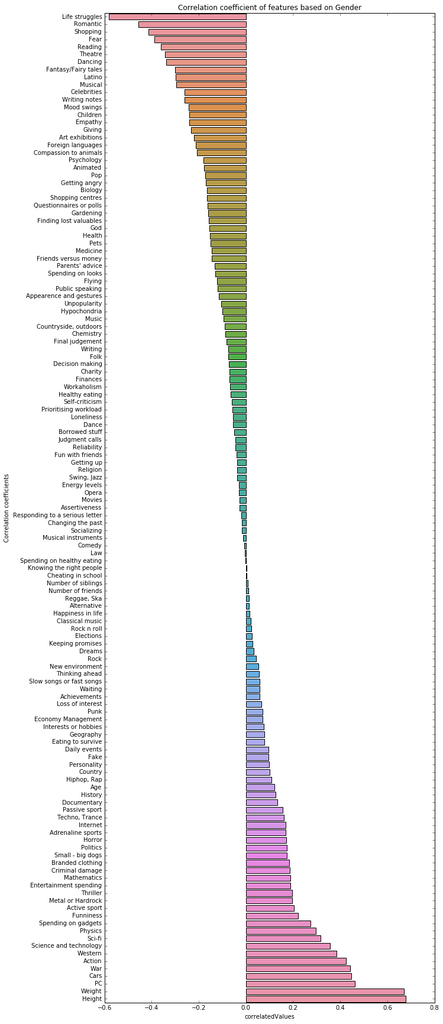

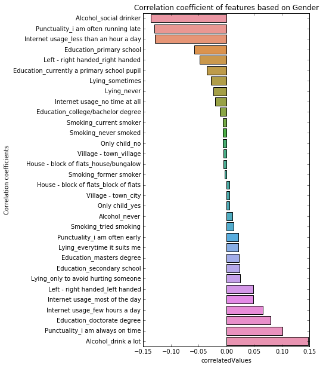

```python
def plotCorrelation(variable, mainDataFrame, map):
    figsize = (10,30)
    def calculateCorrelation(variable, df, cols, figsize):
        labels = []
        values = []
        for c in cols:
            labels.append(c)
            values.append(np.corrcoef(df[c], df[variable])[0,1])
        correlations = pd.DataFrame({'features': labels, 'correlatedValues': values})
        correlations = correlations.sort_values(by = 'correlatedValues')
        fig, ax = plt.subplots(figsize= figsize)
        sns.barplot(x=correlations.correlatedValues, y = correlations['features'],  ax = ax)
        ax.set_title("Correlation coefficient of features based on Gender")
        ax.set_ylabel("Correlation coefficients")
        return correlations
    #Take a copy and update the dataset for Gender column
    df = copy.deepcopy(mainDataFrame)
    df.replace(map, inplace = True)

    #correlating integer features
    integerColumns = [c for c in df.columns if df[c].dtype != 'object']
    integerColumns.remove(variable)
    integerCorrelations = calculateCorrelation(variable, df, integerColumns, figsize)

    #correlating categorical data
    categoricalColumns = [c for c in df.columns if df[c].dtype == 'object']
    if categoricalColumns:
        dfDummies = pd.get_dummies(df[categoricalColumns])
        categoricalColumns = dfDummies.columns
        dfDummies[variable] = df[variable]
        categoricalCorrelations = calculateCorrelation(variable, dfDummies, categoricalColumns, (5,10))
    else:
        categoricalCorrelations = 0
    return [integerCorrelations, categoricalCorrelations]

correlations_area = plotCorrelation('Gender', df3, {'Gender': {'female': 0, 'male': 1}})
```

The correlation graph suggests women tend to encounter much more life struggles ("I cry when I feel down or things don't go the right way") and feel Romantic (rated high for romantic movies) in contrast to men. Similarly, men have great interest in Cars and PC (PC Software, Hardware).

Weight and Height are obvious differences between men and women which is not surprising.

Interestingly, women in general tend to often run late rather than men are often on time.

```
(0, 300)
```

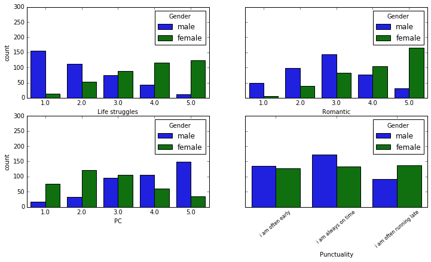

```python
#Everyone loves movies & music, right?
#fig, (ax1, ax2) = plt.subplots(1,2, figsize=(8,4), sharey=True)
import seaborn as sns
import matplotlib.pyplot as plt

fig, ax = plt.subplots(2,2, figsize=(12,6), sharey=True)

sns.countplot(x="Life struggles", hue="Gender", data=df2, ax=ax[0,0])
#ax[0,0].set_xlim(.5,5.5)
#sns.countplot(x="Music", hue="Gender", data=df2, ax=ax[1], palette='hls')
sns.countplot(x="Romantic", hue="Gender", data=df2, ax=ax[0,1])
#ax[0,1].set_xlim(.5,5.5)
ax[0,1].set_ylabel('')
sns.countplot(x="PC", hue="Gender", data=df2, ax=ax[1,0])
sns.countplot(x="Punctuality", hue="Gender", data=df2, ax=ax[1,1])
#ax[1,0].set_ylim(0,400)
#ax[1,1].set_ylim(0,400)
ax[1,1].set_ylabel('')
ax[1,1].set_xticklabels(labels=df2['Punctuality'].unique(), rotation=40, fontsize=8)

plt.ylim(0, 300)
```

```
Blue represents male and green represents female for each of these bar graphs.
```

```
(0, 300)
```

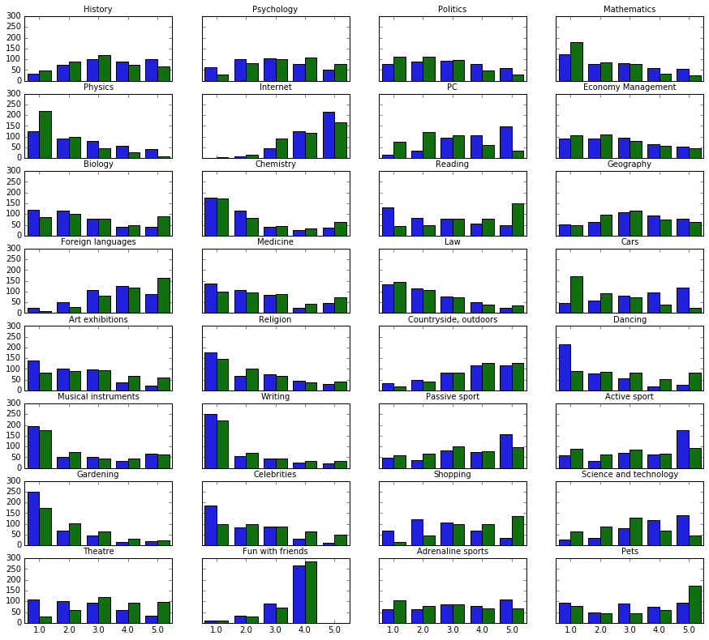

```python
plt_dict = {}

plt_dict = {i:interests.columns[i] for i in range(0,len(interests.columns))}

fig, ax = plt.subplots(8,4,figsize=(15,13), sharey=True, sharex=True)
l  = 0.125  # the left side of the subplots of the figure
r = 0.9    # the right side of the subplots of the figure
b = 0.1   # the bottom of the subplots of the figure
t = 0.9      # the top of the subplots of the figure
ws = 0.2   # the amount of width reserved for blank space between subplots
hs = 0.2   # the amount of height reserved for white space between subplots

plt.subplots_adjust(left=l, bottom=b, right=r, top=t, wspace=ws, hspace=hs)

key = 0

print("Blue represents male and green represents female for each of these bar graphs.")

for i in range(8):
    for j in range(4):
        sns.countplot(df2[plt_dict[key]], hue=df2["Gender"], ax=ax[i,j])
        ax[i,j].set_ylabel('')
        ax[i,j].set_xlabel('')
        #ax[i,j].set_xticklabels(labels=np.arange(0,6), fontsize=8)
        #ax[i,j].set_yticklabels(labels=np.arange(0,400,100), fontsize=8)
        ax[i,j].set_title(plt_dict[key], fontsize=10)
        #ax[i,j].set_xlim(.5,5.5)
        #ax[i,j].set_ylim(0,400)
        ax[i,j].legend_.remove()
        key += 1

plt.ylim(0, 300)
```

```python
education = df2.iloc[:,31:46]

education_aves = pd.Series(df2[education.columns].mean())
education_aves_male = pd.Series(df2_male[education.columns].mean())
education_aves_female = pd.Series(df2_female[education.columns].mean())

education_ave = pd.DataFrame({'category': education.columns, 'male_mean':education_aves_male, 'female_mean':education_aves_female, 'mean':education_aves })
education_ave
```

|  | category | female_mean | male_mean | mean |
| --- | --- | --- | --- | --- |
| History | History | 3.087940 | 3.384422 | 3.224874 |
| Psychology | Psychology | 3.288945 | 2.871859 | 3.096734 |
| Politics | Politics | 2.341709 | 2.886935 | 2.662060 |
| Mathematics | Mathematics | 2.128141 | 2.610553 | 2.356784 |
| Physics | Physics | 1.788945 | 2.505025 | 2.133166 |
| Internet | Internet | 4.025126 | 4.364322 | 4.212312 |
| PC | PC | 2.597990 | 3.849246 | 3.242462 |
| Economy Management | Economy Management | 2.542714 | 2.753769 | 2.658291 |
| Biology | Biology | 2.864322 | 2.422111 | 2.653266 |
| Chemistry | Chemistry | 2.266332 | 2.082915 | 2.203518 |
| Reading | Reading | 3.615578 | 2.522613 | 3.059045 |
| Geography | Geography | 2.979899 | 3.201005 | 3.101759 |
| Foreign languages | Foreign languages | 3.974874 | 3.505025 | 3.744975 |
| Medicine | Medicine | 2.655779 | 2.331658 | 2.532663 |
| Law | Law | 2.195980 | 2.281407 | 2.286432 |

```
Black dotted line represents the mean for education features rated by men and women.
```

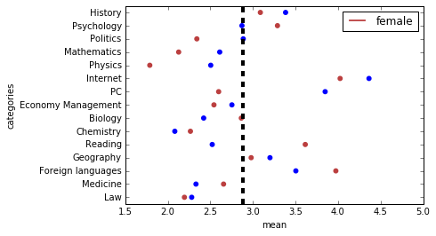

```python
ax1 = sns.pointplot(x='female_mean', y='category', data=education_ave, color="#bb3f3f", join=False)
ax2 = sns.pointplot(x='male_mean', y='category', data=education_ave, join=False)
ax1.set_xlabel('mean')
ax1.set_ylabel('categories')
ax1.legend(['female'])

plt.axvline(x=np.mean(education_ave['mean']), color='k', lw=4, ls='dashed')
print("Black dotted line represents the mean for education features rated by men and women.")
```

If you notice from the above graph: Physics, PC, and Reading have drastic difference between the two genders.

```python
df2_female = df2.loc[df2['Gender'] == 'female']
df2_male = df2.loc[df2['Gender'] == 'male']

spend_aves = pd.Series(df2[spending.columns].mean())
spend_aves_male = pd.Series(df2_male[spending.columns].mean())
spend_aves_female = pd.Series(df2_female[spending.columns].mean())

spend_ave = pd.DataFrame({'category': spending.columns, 'male_mean':spend_aves_male, 'female_mean':spend_aves_female, 'mean':spend_aves })
spend_ave
```

|  | category | female_mean | male_mean | mean |
| --- | --- | --- | --- | --- |
| Finances | Finances | 3.097990 | 2.937186 | 3.017588 |
| Shopping centres | Shopping centres | 3.427136 | 2.989950 | 3.208543 |
| Branded clothing | Branded clothing | 2.846734 | 3.331658 | 3.089196 |
| Entertainment spending | Entertainment spending | 3.022613 | 3.472362 | 3.247487 |
| Spending on looks | Spending on looks | 3.246231 | 2.929648 | 3.087940 |
| Spending on gadgets | Spending on gadgets | 2.577889 | 3.291457 | 2.934673 |
| Spending on healthy eating | Spending on healthy eating | 3.545226 | 3.542714 | 3.543970 |

```
Both men and women provide rating on 1-5 scale average is 3.02, however, spending responses are slightly higher at 3.16.
 This represents a modest over-confidence of young adults in financial discipline.
Black dotted line represents the mean for spending feature rated by men and women.
```

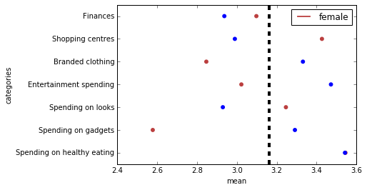

```python
ax1 = sns.pointplot(x='female_mean', y='category', data=spend_ave, color="#bb3f3f", join=False)
ax2 = sns.pointplot(x='male_mean', y='category', data=spend_ave, join=False)
ax1.set_xlabel('mean')
ax1.set_ylabel('categories')
ax1.legend(['female'])

plt.axvline(x=np.mean(spend_ave['mean']), color='k', lw=4, ls='dashed')

print('Both men and women provide rating on 1-5 scale average is {:.2f}, however, spending responses are slightly higher at {:.2f}. \n This represents a modest over-confidence of young adults in financial discipline.'
      .format(df2['Finances'].mean(),np.mean(spend_aves)))

print("Black dotted line represents the mean for spending feature rated by men and women.")
```

In terms of the gender differences in financial matter, males and females think quite differently except for spending on healthy eating.

```python
#Logistic Regression to predict gender of a person
#from sklearn.cross_validation import KFold, train_test_split, cross_val_score
from sklearn.model_selection import GridSearchCV, KFold, train_test_split, cross_val_score
from sklearn.linear_model import LogisticRegression
```

```python
#set up data for modeling
#Update female value to 0
df2.loc[df2['Gender'] == 'female', 'Gender'] = 0
#Update male value to 1
df2.loc[df2['Gender'] == 'male', 'Gender'] = 1
#Remove all these unnecessary columns from dataset.
df2.drop(['Internet usage','Lying','Punctuality','Smoking','Alcohol','Left - right handed','Education','Only child','Village - town','House - block of flats'], axis=1, inplace=True)
```

```python
#Remove Gender column data in dataset
x = df2.drop('Gender', axis=1)
#Provide Gender column data
y = df2['Gender']
#Convert y from object to integer type
y=y.astype('int')

x_train, x_test, y_train, y_test = train_test_split(x, y, test_size=.3, random_state=4)

kf = KFold(n_splits=5)
```

```python
#Standardization helps get better prediction result
from sklearn.preprocessing import StandardScaler
scaler = StandardScaler()
scaler.fit(x_train)
x_train=scaler.transform(x_train)
x_test=scaler.transform(x_test)
```

```python
logreg = LogisticRegression()
#5-fold cross validation for logistic regression on entire data set
scores = cross_val_score(logreg, x, y, cv=5, scoring='accuracy')
scores.mean()
```

```
0.92458860759493666
```

```python
#GridSearchCV
#You can use grid search to find out the best C value. Basically smaller C specifies stronger regularization.
param_grid = {'C': [0.001, 0.01, 0.1, 1, 10, 100, 1000] }
gs_logreg = GridSearchCV(logreg, param_grid=param_grid, cv=kf)

best_model = gs_logreg.fit(x_train, y_train)
print(best_model.best_score_)
print(best_model.best_params_)
print(best_model.best_estimator_)
```

```
0.938958707361
{'C': 0.1}
LogisticRegression(C=0.1, class_weight=None, dual=False, fit_intercept=True,
          intercept_scaling=1, max_iter=100, multi_class='ovr', n_jobs=1,
          penalty='l2', random_state=None, solver='liblinear', tol=0.0001,
          verbose=0, warm_start=False)
```

```python
#fit Logistic Regression model, eval scoring
logreg = LogisticRegression()
model = logreg.fit(x_train, y_train)

print('Average accuracy on each (KFold) set: {:.3f}'.format(np.mean(cross_val_score(logreg, x_train, y_train, cv=kf))))
print('Prediction accuracy on test set is: {:.3f}'.format(logreg.score(x_test, y_test)))
```

```
Average accuracy on each (KFold) set: 0.923
Prediction accuracy on test set is: 0.916
```

```python
print('Prediction accuracy on test set with best model from Grid Search CV is: {:.3f}'.format(best_model.score(x_test, y_test)))
```

```
Prediction accuracy on test set with best model from Grid Search CV is: 0.916
```

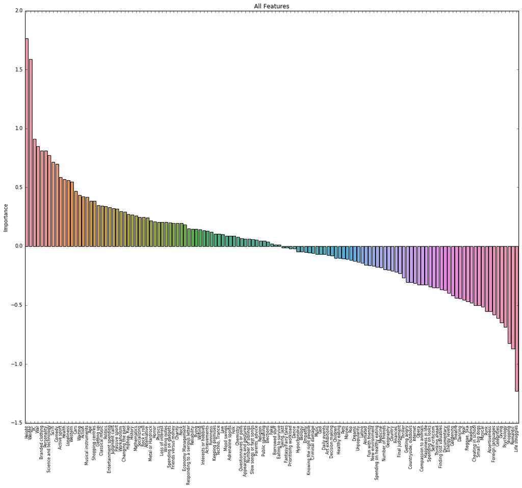

```python
#plot of all feature's importance
coeff_df = pd.DataFrame(data=logreg.coef_[0], index=[x.columns], columns=['Feature_Import'])
coeff_df = coeff_df.sort_values(by='Feature_Import', ascending=False)

fig, ax = plt.subplots(1,1, figsize=(18,15))

sns.barplot(x=coeff_df.index, y=coeff_df['Feature_Import'], ax=ax)
ax.set_title('All Features')
ax.set_xticklabels(labels=coeff_df.index, size=8, rotation=90)
ax.set_ylabel('Importance')
```

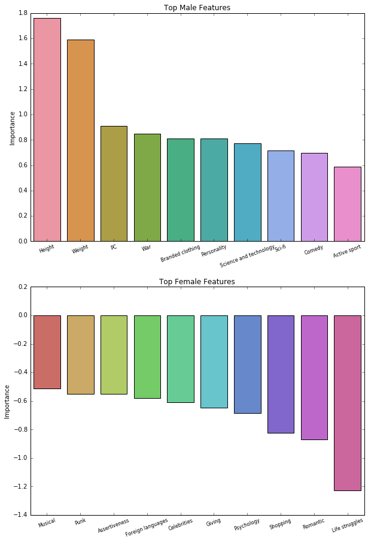

```python
fig, (ax1, ax2) = plt.subplots(2,1, figsize=(10,15))

sns.barplot(x=coeff_df.index[:10], y=coeff_df['Feature_Import'].head(10), ax=ax1)
ax1.set_title('Top Male Features')
ax1.set_ylabel('Importance')
ax1.set_xticklabels(labels=coeff_df.index[:10], fontsize=8, rotation=20)

sns.barplot(x=coeff_df.index[-10:], y=coeff_df['Feature_Import'].tail(10), ax=ax2, palette='hls')
ax2.set_title('Top Female Features')
ax2.set_ylabel('Importance')
ax2.set_xticklabels(labels=coeff_df.index[-10:], fontsize=8, rotation=20)
```

Below are my insights that describe features of men:

1. If you look at the top features that men have, you can conclude if a person loves to be active and likes technology and action movies, then the person is very likely a man.
2. If you notice, in current IT industry, there is a huge number of gender inequality. There are lot of organizations and even companies that are promoting women to join Tech companies.
3. Since men love active sports, that can be related to why they love War and Sci-Fi films as they are fast paced action films. This attitude makes sense of why men have rated highly for Cars.

Below are my insights that describe features of women:

1. Women are tend to be more emotional which is why we can see Life struggles and Psychology is very important and more personal to them.
2. They are more concerned about their appearance which is why they end up spending more time on their looks, this is related to why they end up shopping and rated high for celebrities.
3. We can also see that women are mostly light hearted due to their interest in musicals and their compassion to animals and their preference of watching romantic movies.

Finally, this project has allowed me to become more comfortable to use Jupyter notebook for python. I learned how to use matplotlib and seaborn for graphs and pandas dataframe for doing analysis.

For future works, I could run some more ML algorithms with selective features rather than using almost all columns in the dataset as features (the reason being, more features could cause for less accuracy to predict).